# W16 Final exam

## Final exam

- Question 1 to 8
- 滿分100分。
- 程式碼內容會列入評分標準
- 請將程式碼、圖片檔PNG上傳至ee-class期末考
- 請提前上傳，請勿遲交
- deadline: 12:00

## Question 1 (10%)

- 1.1 請匯入檔案”河川水質監測資料”
- 1.1 讀取檔案進來，並將[‘-’]符號設為NaN，並設定low_memory=False (5%)

```
##         siteid sitename        siteengname  ... itemvalue    itemunit note
## 0         1001     忠孝大橋  Jhongshou Bridge.  ...       6.5         NaN  NaN
## 1         1001     忠孝大橋  Jhongshou Bridge.  ...      18.6           ℃  NaN
## 2         1001     忠孝大橋  Jhongshou Bridge.  ...      7.23              NaN
## 3         1001     忠孝大橋  Jhongshou Bridge.  ...       562  μmho/cm25℃  NaN
## 4         1001     忠孝大橋  Jhongshou Bridge.  ...      18.0           ℃  NaN
## ...        ...      ...                ...  ...       ...         ...  ...
## 958942    1724     歪仔歪橋   Waizihwai Bridge  ...       NaN        mg/L  NaN
## 958943    1724     歪仔歪橋   Waizihwai Bridge  ...       NaN        mg/L  NaN
## 958944    1724     歪仔歪橋   Waizihwai Bridge  ...       NaN        mg/L  NaN
## 958945    1724     歪仔歪橋   Waizihwai Bridge  ...       NaN        mg/L  NaN
## 958946    1724     歪仔歪橋   Waizihwai Bridge  ...       NaN        mg/L  NaN
##
## [958947 rows x 18 columns]
```

## Question 1 (10%)

- 1.2 將itemvalue欄位中”<“與”<“符號刪掉，並轉檔為float(5%)

```
## <class 'pandas.core.frame.DataFrame'>
## RangeIndex: 958947 entries, 0 to 958946
## Data columns (total 18 columns):
##  #   Column               Non-Null Count   Dtype
## ---  ------               --------------   -----
##  0   siteid               958947 non-null  int64
##  1   sitename             957396 non-null  object
##  2   siteengname          956031 non-null  object
##  3   county               958947 non-null  object
##  4   township             27560 non-null   object
##  5   basin                958947 non-null  object
##  6   river                958947 non-null  object
##  7   twd97lon             958947 non-null  float64
##  8   twd97lat             958947 non-null  float64
##  9   twd97tm2x            958947 non-null  float64
##  10  twd97tm2y            958947 non-null  float64
##  11  sampledate           958947 non-null  object
##  12  itemname             958947 non-null  object
##  13  itemengname          958947 non-null  object
##  14  itemengabbreviation  958947 non-null  object
##  15  itemvalue            414764 non-null  float64
##  16  itemunit             925738 non-null  object
##  17  note                 45745 non-null   object
## dtypes: float64(5), int64(1), object(12)
## memory usage: 131.7+ MB
```

## Question 2 (10%)

- 2.1 將sampledate轉成時間格式(datetime)存成date欄位名稱（提示：加入errors=‘coerce’） (5%)
- 2.2 將sampledate中的年、月、日獨立存成year、month、day欄位(5%)

```
##          twd97tm2y          sampledate  itemname  ...    year month   day
## 0       2771535.67 2022-01-05 07:25:00  河川污染分類指標  ...  2022.0   1.0   5.0
## 1       2771535.67 2022-01-05 07:25:00        水溫  ...  2022.0   1.0   5.0
## 2       2771535.67 2022-01-05 07:25:00       酸鹼值  ...  2022.0   1.0   5.0
## 3       2771535.67 2022-01-05 07:25:00       導電度  ...  2022.0   1.0   5.0
## 4       2771535.67 2022-01-05 07:25:00        氣溫  ...  2022.0   1.0   5.0
## ...            ...                 ...       ...  ...     ...   ...   ...
## 958942  2733072.79 2024-10-11 10:15:00         鎘  ...  2024.0  10.0  11.0
## 958943  2733072.79 2024-10-11 10:15:00         硒  ...  2024.0  10.0  11.0
## 958944  2733072.79 2024-10-11 10:15:00         銀  ...  2024.0  10.0  11.0
## 958945  2733072.79 2024-10-11 10:15:00       六價鉻  ...  2024.0  10.0  11.0
## 958946  2733072.79 2024-10-11 10:15:00         汞  ...  2024.0  10.0  11.0
##
## [958947 rows x 11 columns]
```

## Question 3 (5%)

- 3 將水質參數(itemvalue)轉成欄位資料（e.g. 檔名df_water_pivot）(5%)

```
## itemname     sitename county   basin river  ...      鋅      錳      鎘      鎳
## 0         七結橋(取代得子口橋)    宜蘭縣  得子口溪流域  得子口溪  ...    NaN    NaN    NaN    NaN
## 1         七結橋(取代得子口橋)    宜蘭縣  得子口溪流域  得子口溪  ...    NaN    NaN    NaN    NaN
## 2         七結橋(取代得子口橋)    宜蘭縣  得子口溪流域  得子口溪  ...  0.016  0.069  0.001    NaN
## 3         七結橋(取代得子口橋)    宜蘭縣  得子口溪流域  得子口溪  ...    NaN    NaN    NaN    NaN
## 4         七結橋(取代得子口橋)    宜蘭縣  得子口溪流域  得子口溪  ...    NaN    NaN    NaN    NaN
## ...               ...    ...     ...   ...  ...    ...    ...    ...    ...
## 26855             龜山橋    苗栗縣   後龍溪流域   後龍溪  ...  0.015  0.025  0.001  0.005
## 26856             龜山橋    苗栗縣   後龍溪流域   後龍溪  ...  0.016  0.033  0.001  0.005
## 26857             龜山橋    苗栗縣   後龍溪流域   後龍溪  ...    NaN    NaN    NaN    NaN
## 26858             龜山橋    苗栗縣   後龍溪流域   後龍溪  ...  0.022  0.012  0.001  0.005
## 26859             龜山橋    苗栗縣   後龍溪流域   後龍溪  ...    NaN    NaN    NaN    NaN
##
## [26860 rows x 36 columns]
```

## Question 4 (10%)

- 4 計算每個河川區域(river)歷年總平均值(e.g. df_water_mean)(請把年月日欄位拿掉)、每個河川區域各年度平均值(e.g. df_water_mean_year)(請把月日欄位拿掉)、每個河川區域各月份總平均值(e.g. df_water_mean_month)(請把年日欄位拿掉)、以及每個河川區域各縣市總平均值(e.g. df_water_county)(請把年月日欄位拿掉)
- 4.1 計算每個河川區域(river)歷年總平均值(e.g. df_water_mean)(請把年月日欄位拿掉)

```
## itemname river     亞硝酸鹽氮       六價鉻  ...         錳      鎘         鎳
## 0          三峽河  0.065818  0.002000  ...  0.062625  0.001  0.005023
## 1          三棧溪  0.003667  0.002000  ...  0.014000  0.001  0.005500
## 2          三爺溪  0.254000  0.007143  ...  0.135571  0.001  0.014571
## 3          三疊溪  0.295000  0.002000  ...  0.611074  0.001  0.010773
## 4          上坪溪  0.002000  0.002000  ...  0.005636  0.001  0.005000
## ..         ...       ...       ...  ...       ...    ...       ...
## 85         高屏溪  0.097071  0.002000  ...  0.422101  0.001  0.008047
## 86         鳳山溪  0.122037  0.002000  ...  0.086621  0.001  0.007806
## 87         鹽水溪  0.197593  0.002000  ...  0.188523  0.001  0.014496
## 88         鹽港溪  0.103063  0.002000  ...  0.210750  0.001  0.005433
## 89         鹿野溪  0.012000  0.002000  ...  1.595333  0.001  0.033667
##
## [90 rows x 29 columns]
```

## Question 4 (10%)

- 4.2 每個河川區域各年度平均值(e.g. df_water_mean_year)(請把月日欄位拿掉)

```
## itemname river    year     亞硝酸鹽氮    六價鉻  ...         鋅         錳      鎘         鎳
## 0          三峽河  2017.0  0.009000  0.002  ...  0.014000  0.063400  0.001       NaN
## 1          三峽河  2018.0       NaN  0.002  ...  0.011000  0.098333  0.001  0.005000
## 2          三峽河  2019.0  0.112000  0.002  ...  0.009200  0.055200  0.001  0.005200
## 3          三峽河  2020.0  0.110000  0.002  ...  0.011600  0.140400  0.001  0.005000
## 4          三峽河  2021.0  0.077500  0.002  ...  0.008375  0.057375  0.001  0.005000
## ..         ...     ...       ...    ...  ...       ...       ...    ...       ...
## 581        鹽港溪  2022.0  0.101333  0.002  ...  0.018750  0.246917  0.001  0.005750
## 582        鹽港溪  2023.0  0.126667  0.002  ...  0.022333  0.231000  0.001  0.005167
## 583        鹽港溪  2024.0  0.116333  0.002  ...  0.028556  0.195889  0.001  0.005778
## 584        鹿野溪  2023.0       NaN  0.002  ...  0.145000  1.790000  0.001  0.047000
## 585        鹿野溪  2024.0  0.012000  0.002  ...  0.066000  1.498000  0.001  0.027000
##
## [586 rows x 30 columns]
```

## Question 4 (10%)

- 4.3 每個河川區域各月份總平均值(e.g. df_water_mean_month)(請把年日欄位拿掉)

```
## itemname river  month   亞硝酸鹽氮    六價鉻  ...         鋅        錳      鎘      鎳
## 0          三峽河    1.0  0.0715  0.002  ...  0.012100  0.08180  0.001  0.005
## 1          三峽河    2.0     NaN    NaN  ...       NaN      NaN    NaN    NaN
## 2          三峽河    3.0  0.0090  0.002  ...  0.007000  0.02000  0.001    NaN
## 3          三峽河    4.0     NaN  0.002  ...  0.009286  0.08400  0.001  0.005
## 4          三峽河    5.0     NaN  0.002  ...  0.010750  0.05025  0.001  0.005
## ...        ...    ...     ...    ...  ...       ...      ...    ...    ...
## 1061       鹿野溪    8.0     NaN  0.002  ...  0.128000  2.88000  0.001  0.049
## 1062       鹿野溪    9.0     NaN    NaN  ...       NaN      NaN    NaN    NaN
## 1063       鹿野溪   10.0     NaN  0.002  ...  0.145000  1.79000  0.001  0.047
## 1064       鹿野溪   11.0     NaN    NaN  ...       NaN      NaN    NaN    NaN
## 1065       鹿野溪   12.0     NaN    NaN  ...       NaN      NaN    NaN    NaN
##
## [1066 rows x 30 columns]
```

## Question 4 (10%)

- 4.4 每個河川區域各縣市總平均值(e.g. df_water_county)(請把年月日欄位拿掉)

```
## itemname river county     亞硝酸鹽氮       六價鉻  ...         鋅         錳      鎘         鎳
## 0          三峽河    新北市  0.065818  0.002000  ...  0.010875  0.062625  0.001  0.005023
## 1          三棧溪    花蓮縣  0.003667  0.002000  ...  0.010739  0.014000  0.001  0.005500
## 2          三爺溪    臺南市  0.254000  0.007143  ...  0.031000  0.135571  0.001  0.014571
## 3          三疊溪    嘉義縣  0.295000  0.002000  ...  0.031926  0.611074  0.001  0.010773
## 4          上坪溪    新竹縣  0.002000  0.002000  ...  0.012545  0.005636  0.001  0.005000
## ..         ...    ...       ...       ...  ...       ...       ...    ...       ...
## 105        鳳山溪    新竹縣  0.122037  0.002000  ...  0.015284  0.086621  0.001  0.007806
## 106        鹽水溪    臺南市  0.197593  0.002000  ...  0.026823  0.188523  0.001  0.014496
## 107        鹽港溪    新竹市  0.134182  0.002000  ...  0.024771  0.198063  0.001  0.005476
## 108        鹽港溪    新竹縣  0.034600  0.002000  ...  0.017900  0.241200  0.001  0.005333
## 109        鹿野溪    臺東縣  0.012000  0.002000  ...  0.092333  1.595333  0.001  0.033667
##
## [110 rows x 30 columns]
```

## Question 5 (20%)

- 5.1 河川污染指數(RPI)是根據生化需氧量、溶氧量、氨氮及懸浮固體等四項理化水質參數組成，用以根據其數值來對污染程度加以分類。
- 5.1 請根據河川污染分類指標(RPI)，將df_water_mean檔案中RPI分類為”未(稍)受污染：RPI<=2.0”，“輕度污染：2.0<RPI<=3.0”，“中度污染：3.1<=RPI<=6.0”，“重度污染：RPI>6.0” (10%)

```
## itemname         銅         鋅         錳      鎘         鎳     污染等級
## 0         0.001958  0.010875  0.062625  0.001  0.005023     輕度污染
## 1         0.002522  0.010739  0.014000  0.001  0.005500  未(稍)受污染
## 2         0.026714  0.031000  0.135571  0.001  0.014571     中度污染
## 3         0.004259  0.031926  0.611074  0.001  0.010773     中度污染
## 4         0.002455  0.012545  0.005636  0.001  0.005000  未(稍)受污染
## ..             ...       ...       ...    ...       ...      ...
## 85        0.009285  0.042490  0.422101  0.001  0.008047     中度污染
## 86        0.003647  0.015284  0.086621  0.001  0.007806  未(稍)受污染
## 87        0.006336  0.026823  0.188523  0.001  0.014496     中度污染
## 88        0.003456  0.022750  0.210750  0.001  0.005433     輕度污染
## 89        0.023667  0.092333  1.595333  0.001  0.033667     輕度污染
##
## [90 rows x 6 columns]
```

## Question 5 (20%)

- 5.2 請將df_water_mean檔案中，屬於中度汙染的河川挑選出來存檔(df_water_mean_中)，再利用RPI由最大至最小排序，請將RPI排名前10高的資料儲存出來(例如可存為df_water_mean_中10max)，表示為汙染嚴重的前十大河川。
- 提示: 排序後，可將此十大河川的名稱儲存，再用isin萃取資料
- 5.2 df_water_mean_中10max結果 (4%)

```
## itemname   river     亞硝酸鹽氮       六價鉻  ...         鎘         鎳  污染等級
## 2            三爺溪  0.254000  0.007143  ...  0.001000  0.014571  中度污染
## 3            三疊溪  0.295000  0.002000  ...  0.001000  0.010773  中度污染
## 6            二仁溪  0.209489  0.002000  ...  0.001000  0.015489  中度污染
## 9            六重溪  0.116000  0.002000  ...  0.001000  0.006750  中度污染
## 15           南崁溪  0.629270  0.002000  ...  0.001006  0.007721  中度污染
## 17        南港溪(苗)  0.125286  0.002000  ...  0.001000  0.005750  中度污染
## 32           急水溪  0.405867  0.002000  ...  0.001000  0.006924  中度污染
## 36          新虎尾溪  0.132735  0.002000  ...  0.001000  0.010052  中度污染
## 48           武洛溪  0.181000  0.002000  ...  0.001000  0.005500  中度污染
## 56        牛稠溪(屏)  0.493000  0.002000  ...  0.001000  0.007750  中度污染
##
## [10 rows x 30 columns]
```

## Question 5 (20%)

- 5.3 利用各年長期平均資料(df_water_mean_year)檔案，萃取此10大河川各年資料存檔(如df_water_mean_year_中10max)
- 提示: 排序後，可將此十大河川的名稱儲存，再用isin萃取符合十大河川名稱的df_water_mean_year資料
- 5.3 df_water_mean_year_中10max結果 (3%)

```
## itemname   river    year     亞硝酸鹽氮  ...         錳         鎘         鎳
## 16           三爺溪  2023.0       NaN  ...  0.197000  0.001000  0.009000
## 17           三爺溪  2024.0  0.254000  ...  0.125333  0.001000  0.015500
## 18           三疊溪  2017.0  0.016000  ...  0.756250  0.001000       NaN
## 19           三疊溪  2018.0  0.408000  ...  0.944333  0.001000  0.053000
## 20           三疊溪  2019.0  0.256000  ...  0.380000  0.001000  0.011000
## 21           三疊溪  2020.0  0.235000  ...  0.514500  0.001000  0.011500
## 22           三疊溪  2021.0  0.789000  ...  0.562750  0.001000  0.005000
## 23           三疊溪  2022.0  0.161000  ...  0.566750  0.001000  0.005000
## 24           三疊溪  2023.0  0.406000  ...  0.548000  0.001000  0.005000
## 25           三疊溪  2024.0  0.089000  ...  0.587333  0.001000  0.005000
## 36           二仁溪  2017.0       NaN  ...  0.382778  0.001000       NaN
## 37           二仁溪  2018.0  0.205400  ...  0.132312  0.001000  0.013000
## 38           二仁溪  2019.0  0.352000  ...  0.144611  0.001000  0.029167
## 39           二仁溪  2020.0  0.098250  ...  0.149429  0.001000  0.012500
```

[output cut: 44 more lines]

## Question 5 (20%)

- 5.4 利用各月長期平均(df_water_mean_month)資料，萃取此10大河川各月長期平均資料存檔(如df_water_mean_month_中10max)
- 提示: 排序後，可將此十大河川的名稱儲存，再用isin萃取符合十大河川名稱的df_water_mean_month資料
- 5.4 df_water_mean_month_中10max結果 (3%)

```
## itemname   river  month  亞硝酸鹽氮    六價鉻  ...      鋅      錳      鎘      鎳
## 24           三爺溪    1.0  0.254  0.002  ...  0.020  0.095  0.001  0.005
## 25           三爺溪    2.0    NaN    NaN  ...    NaN    NaN    NaN    NaN
## 26           三爺溪    3.0    NaN    NaN  ...    NaN    NaN    NaN    NaN
## 27           三爺溪    4.0    NaN    NaN  ...    NaN    NaN    NaN    NaN
## 28           三爺溪    5.0    NaN  0.002  ...  0.031  0.152  0.001  0.031
## ..           ...    ...    ...    ...  ...    ...    ...    ...    ...
## 679       牛稠溪(屏)    8.0    NaN  0.002  ...  0.195  0.289  0.001  0.014
## 680       牛稠溪(屏)    9.0    NaN    NaN  ...    NaN    NaN    NaN    NaN
## 681       牛稠溪(屏)   10.0    NaN  0.002  ...  0.016  0.291  0.001  0.005
## 682       牛稠溪(屏)   11.0    NaN    NaN  ...    NaN    NaN    NaN    NaN
## 683       牛稠溪(屏)   12.0    NaN    NaN  ...    NaN    NaN    NaN    NaN
##
## [120 rows x 30 columns]
```

## 設定中文呈現

```python
#import matplotlib.pyplot as plt
#import matplotlib.font_manager as fm
#path_font = '/content/drive/MyDrive/Course/111-1_data_process/微軟正黑體-1.ttf'
#fm.fontManager.addfont(path_font)
#plt.rc('font', family='Microsoft JhengHei')
```

## Question 6 (15%)

- 6.1 產生兩個次圖，左圖利用bar畫圖，繪製上述5.2所選取之排名前10大的中度汙染河川，將其歷年總平均值’RPI’(如df_water_mean_中10max)繪製成bar圖
- 6.2 右圖繪製排名前10大的中度汙染河川的各年度’生化需氧量’平均值(如 df_water_mean_year_中10max)，存檔成PNG檔，與程式一同上傳。請與範例圖片一致。
- 備註：figsize=(16,5)，fontsize = 12

## Question 6 (15%)

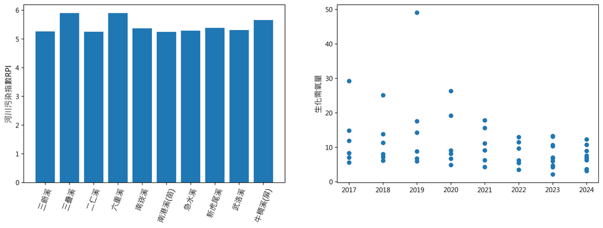

## Question 7 (20%)

- 7.1 利用df_water_mean檔案，利用’亞硝酸鹽氮’,‘大腸桿菌群’,‘總有機碳’,‘總磷’，使用OLS multiple regression多元回歸預測’河川污染分類指標’迴歸關係(10%)

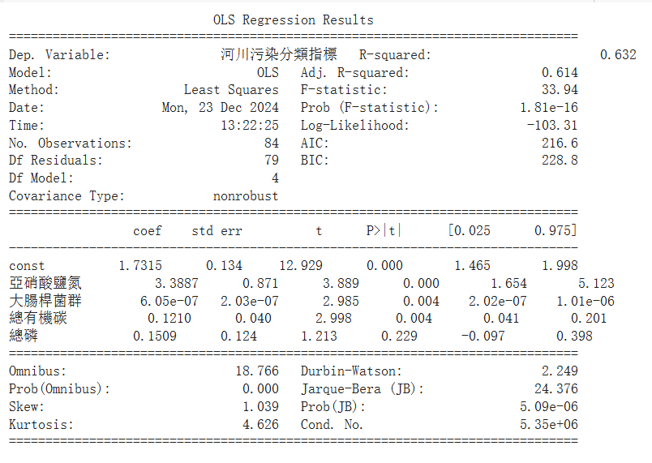

## Question 7 (20%)

- 7.2 使用Random forest regression演算法計算’亞硝酸鹽氮’,‘大腸桿菌群’,‘總有機碳’,’總磷’幾個指數對於’河川污染分類指標’的預測能力。(10%)
- 提示: n_estimators=100, random_state=20

```
RandomForestRegressor(random_state=20)
```

```
## Mean Squared Error: 0.8986328924171425
```

```
## R-squared: 0.5574239648518879
```

## Question 8 (10%)

- 8.1 使用df_water_mean檔案並利用seaborn的迴歸套件繪製成’亞硝酸鹽氮’,‘大腸桿菌群’,‘總有機碳’,’總磷’四個指標與河川污染分類指標的迴歸圖，存成PNG圖檔上傳，figsize=(10, 7)(10%)

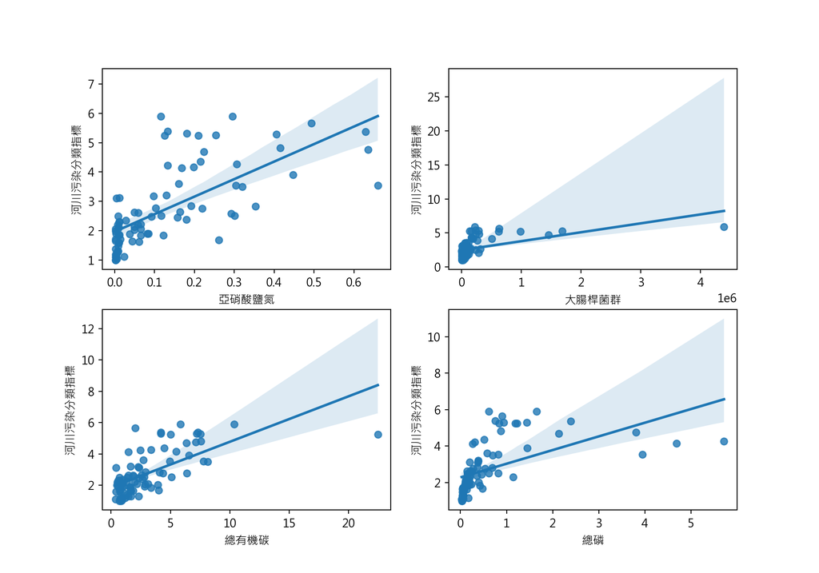